# Risk Factor Analysis

## Outcome Variable

**Outcome Variable:** stunted

## Predictor Variables

**Intervention Variable:** predfeed36

**Adjustment Set:**

unadjusted

## Stratifying Variables

The analysis was stratified on these variable(s):

- agecat
- studyid
- country

## Data Summary

| agecat | studyid | country | predfeed36 | stunted | n_cell | n |
| --- | --- | --- | --- | --- | --- | --- |
| Birth | ki0047075b-MAL-ED | BANGLADESH | 0 | 0 | 95 | 243 |
| Birth | ki0047075b-MAL-ED | BANGLADESH | 0 | 1 | 23 | 243 |
| Birth | ki0047075b-MAL-ED | BANGLADESH | 1 | 0 | 107 | 243 |
| Birth | ki0047075b-MAL-ED | BANGLADESH | 1 | 1 | 18 | 243 |
| Birth | ki0047075b-MAL-ED | BRAZIL | 0 | 0 | 141 | 185 |
| Birth | ki0047075b-MAL-ED | BRAZIL | 0 | 1 | 15 | 185 |
| Birth | ki0047075b-MAL-ED | BRAZIL | 1 | 0 | 25 | 185 |
| Birth | ki0047075b-MAL-ED | BRAZIL | 1 | 1 | 4 | 185 |
| Birth | ki0047075b-MAL-ED | INDIA | 0 | 0 | 155 | 198 |
| Birth | ki0047075b-MAL-ED | INDIA | 0 | 1 | 27 | 198 |
| Birth | ki0047075b-MAL-ED | INDIA | 1 | 0 | 11 | 198 |
| Birth | ki0047075b-MAL-ED | INDIA | 1 | 1 | 5 | 198 |
| Birth | ki0047075b-MAL-ED | NEPAL | 0 | 0 | 130 | 172 |
| Birth | ki0047075b-MAL-ED | NEPAL | 0 | 1 | 16 | 172 |
| Birth | ki0047075b-MAL-ED | NEPAL | 1 | 0 | 24 | 172 |
| Birth | ki0047075b-MAL-ED | NEPAL | 1 | 1 | 2 | 172 |
| Birth | ki0047075b-MAL-ED | PERU | 0 | 0 | 135 | 273 |
| Birth | ki0047075b-MAL-ED | PERU | 0 | 1 | 20 | 273 |
| Birth | ki0047075b-MAL-ED | PERU | 1 | 0 | 106 | 273 |
| Birth | ki0047075b-MAL-ED | PERU | 1 | 1 | 12 | 273 |
| Birth | ki0047075b-MAL-ED | SOUTH AFRICA | 0 | 0 | 211 | 236 |
| Birth | ki0047075b-MAL-ED | SOUTH AFRICA | 0 | 1 | 22 | 236 |
| Birth | ki0047075b-MAL-ED | SOUTH AFRICA | 1 | 0 | 1 | 236 |
| Birth | ki0047075b-MAL-ED | SOUTH AFRICA | 1 | 1 | 2 | 236 |
| Birth | ki0047075b-MAL-ED | TANZANIA, UNITED REPUBLIC OF | 0 | 0 | 102 | 121 |
| Birth | ki0047075b-MAL-ED | TANZANIA, UNITED REPUBLIC OF | 0 | 1 | 18 | 121 |
| Birth | ki0047075b-MAL-ED | TANZANIA, UNITED REPUBLIC OF | 1 | 0 | 1 | 121 |
| Birth | ki0047075b-MAL-ED | TANZANIA, UNITED REPUBLIC OF | 1 | 1 | 0 | 121 |
| Birth | ki1000109-EE | PAKISTAN | 0 | 0 | 0 | 4 |
| Birth | ki1000109-EE | PAKISTAN | 0 | 1 | 2 | 4 |

[output cut: 106 more lines]

The following strata were considered:

- agecat: 24 months, studyid: ki0047075b-MAL-ED, country: BANGLADESH
- agecat: 24 months, studyid: ki0047075b-MAL-ED, country: BRAZIL
- agecat: 24 months, studyid: ki0047075b-MAL-ED, country: INDIA
- agecat: 24 months, studyid: ki0047075b-MAL-ED, country: NEPAL
- agecat: 24 months, studyid: ki0047075b-MAL-ED, country: PERU
- agecat: 24 months, studyid: ki0047075b-MAL-ED, country: SOUTH AFRICA
- agecat: 24 months, studyid: ki0047075b-MAL-ED, country: TANZANIA, UNITED REPUBLIC OF
- agecat: 24 months, studyid: ki1113344-GMS-Nepal, country: NEPAL
- agecat: 24 months, studyid: ki1148112-LCNI-5, country: MALAWI
- agecat: 24 months, studyid: kiGH5241-JiVitA-3, country: BANGLADESH
- agecat: 24 months, studyid: kiGH5241-JiVitA-4, country: BANGLADESH
- agecat: 6 months, studyid: ki0047075b-MAL-ED, country: BANGLADESH
- agecat: 6 months, studyid: ki0047075b-MAL-ED, country: BRAZIL
- agecat: 6 months, studyid: ki0047075b-MAL-ED, country: INDIA
- agecat: 6 months, studyid: ki0047075b-MAL-ED, country: NEPAL
- agecat: 6 months, studyid: ki0047075b-MAL-ED, country: PERU
- agecat: 6 months, studyid: ki0047075b-MAL-ED, country: SOUTH AFRICA
- agecat: 6 months, studyid: ki0047075b-MAL-ED, country: TANZANIA, UNITED REPUBLIC OF
- agecat: 6 months, studyid: ki1000109-EE, country: PAKISTAN
- agecat: 6 months, studyid: ki1000304b-SAS-FoodSuppl, country: INDIA
- agecat: 6 months, studyid: ki1113344-GMS-Nepal, country: NEPAL
- agecat: 6 months, studyid: ki1148112-LCNI-5, country: MALAWI
- agecat: 6 months, studyid: kiGH5241-JiVitA-3, country: BANGLADESH
- agecat: 6 months, studyid: kiGH5241-JiVitA-4, country: BANGLADESH
- agecat: Birth, studyid: ki0047075b-MAL-ED, country: BANGLADESH
- agecat: Birth, studyid: ki0047075b-MAL-ED, country: BRAZIL
- agecat: Birth, studyid: ki0047075b-MAL-ED, country: INDIA
- agecat: Birth, studyid: ki0047075b-MAL-ED, country: NEPAL
- agecat: Birth, studyid: ki0047075b-MAL-ED, country: PERU
- agecat: Birth, studyid: ki0047075b-MAL-ED, country: SOUTH AFRICA
- agecat: Birth, studyid: ki0047075b-MAL-ED, country: TANZANIA, UNITED REPUBLIC OF
- agecat: Birth, studyid: ki1000109-EE, country: PAKISTAN
- agecat: Birth, studyid: kiGH5241-JiVitA-3, country: BANGLADESH
- agecat: Birth, studyid: kiGH5241-JiVitA-4, country: BANGLADESH

### Dropped Strata

Some strata were dropped due to rare outcomes:

- agecat: Birth, studyid: ki0047075b-MAL-ED, country: BRAZIL
- agecat: Birth, studyid: ki0047075b-MAL-ED, country: NEPAL
- agecat: Birth, studyid: ki0047075b-MAL-ED, country: SOUTH AFRICA
- agecat: Birth, studyid: ki0047075b-MAL-ED, country: TANZANIA, UNITED REPUBLIC OF
- agecat: Birth, studyid: ki1000109-EE, country: PAKISTAN
- agecat: 6 months, studyid: ki0047075b-MAL-ED, country: BRAZIL
- agecat: 6 months, studyid: ki0047075b-MAL-ED, country: NEPAL
- agecat: 6 months, studyid: ki0047075b-MAL-ED, country: SOUTH AFRICA
- agecat: 6 months, studyid: ki0047075b-MAL-ED, country: TANZANIA, UNITED REPUBLIC OF
- agecat: 6 months, studyid: ki1000304b-SAS-FoodSuppl, country: INDIA
- agecat: 24 months, studyid: ki0047075b-MAL-ED, country: BRAZIL
- agecat: 24 months, studyid: ki0047075b-MAL-ED, country: SOUTH AFRICA
- agecat: 24 months, studyid: ki0047075b-MAL-ED, country: TANZANIA, UNITED REPUBLIC OF

## Methods Detail

We’re interested in the causal parameters $E[Y_a]$ for all values of $a \in \mathcal{A}$. These parameters represent the mean outcome if, possibly contrary to fact, we intervened to set all units to have $A=a$. Under the randomization and positivity assumptions, these are identified by the statistical parameters $\psi_a=E_W[E_{Y|A,W}(Y|A=a,W)]$. In addition, we’re interested in the mean of $Y$, $E[Y]$ under no intervention (the observed mean). We will estimate these parameters by using SuperLearner to fit the relevant likelihood factors – $E_{Y|A,W}(Y|A=a,W)$ and $p(A=a|W)$, and then updating our likelihood fit using a joint TMLE.

For unadjusted analyses ($W=\{\}$), initial likelihoods were estimated using Lrnr_glm to estimate the simple $E(Y|A)$ and Lrnr_mean to estimate $p(A)$. For adjusted analyses, a small library containing Lrnr_glmnet, Lrnr_xgboost, and Lrnr_mean was used.

Having estimated these parameters, we will then use the delta method to estimate relative risks and attributable risks relative to a prespecified baseline level of $A$.

# Results Detail

## Results Plots

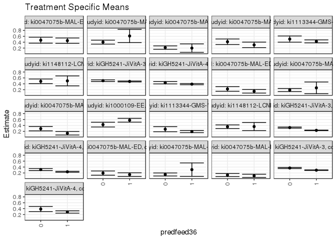

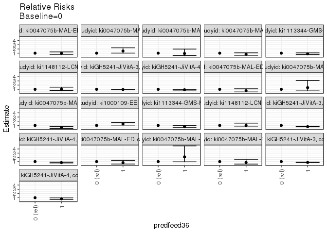

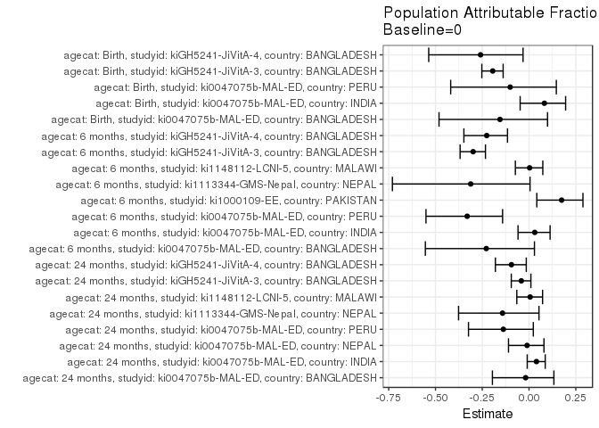

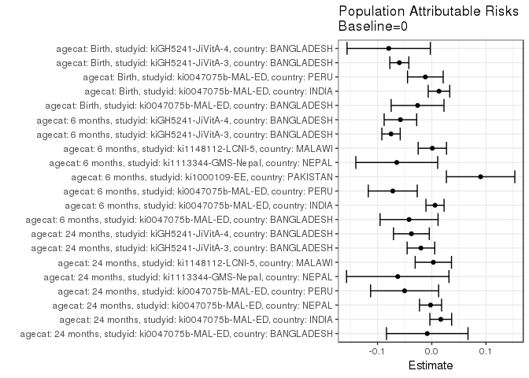

## Results Table

### Parameter: TSM

| agecat | studyid | country | intervention_level | baseline_level | estimate | ci_lower | ci_upper |
| --- | --- | --- | --- | --- | --- | --- | --- |
| Birth | ki0047075b-MAL-ED | BANGLADESH | 0 | NA | 0.1949153 | 0.1232933 | 0.2665372 |
| Birth | ki0047075b-MAL-ED | BANGLADESH | 1 | NA | 0.1440000 | 0.0823254 | 0.2056746 |
| Birth | ki0047075b-MAL-ED | INDIA | 0 | NA | 0.1483516 | 0.0965804 | 0.2001228 |
| Birth | ki0047075b-MAL-ED | INDIA | 1 | NA | 0.3125000 | 0.0848074 | 0.5401926 |
| Birth | ki0047075b-MAL-ED | PERU | 0 | NA | 0.1290323 | 0.0761598 | 0.1819047 |
| Birth | ki0047075b-MAL-ED | PERU | 1 | NA | 0.1016949 | 0.0470606 | 0.1563292 |
| Birth | kiGH5241-JiVitA-3 | BANGLADESH | 0 | NA | 0.3682310 | 0.3484968 | 0.3879653 |
| Birth | kiGH5241-JiVitA-3 | BANGLADESH | 1 | NA | 0.2935755 | 0.2839805 | 0.3031705 |
| Birth | kiGH5241-JiVitA-4 | BANGLADESH | 0 | NA | 0.3862069 | 0.2987826 | 0.4736312 |
| Birth | kiGH5241-JiVitA-4 | BANGLADESH | 1 | NA | 0.2869416 | 0.2462705 | 0.3276127 |
| 6 months | ki0047075b-MAL-ED | BANGLADESH | 0 | NA | 0.2252252 | 0.1473518 | 0.3030987 |
| 6 months | ki0047075b-MAL-ED | BANGLADESH | 1 | NA | 0.1472868 | 0.0860034 | 0.2085703 |
| 6 months | ki0047075b-MAL-ED | INDIA | 0 | NA | 0.1889401 | 0.1367451 | 0.2411351 |
| 6 months | ki0047075b-MAL-ED | INDIA | 1 | NA | 0.2631579 | 0.0647364 | 0.4615794 |
| 6 months | ki0047075b-MAL-ED | PERU | 0 | NA | 0.2896552 | 0.2156875 | 0.3636229 |
| 6 months | ki0047075b-MAL-ED | PERU | 1 | NA | 0.1349206 | 0.0751576 | 0.1946837 |
| 6 months | ki1000109-EE | PAKISTAN | 0 | NA | 0.4275862 | 0.3469512 | 0.5082212 |
| 6 months | ki1000109-EE | PAKISTAN | 1 | NA | 0.5765766 | 0.5114917 | 0.6416614 |
| 6 months | ki1113344-GMS-Nepal | NEPAL | 0 | NA | 0.2718447 | 0.1858414 | 0.3578480 |
| 6 months | ki1113344-GMS-Nepal | NEPAL | 1 | NA | 0.1914894 | 0.1539570 | 0.2290218 |
| 6 months | ki1148112-LCNI-5 | MALAWI | 0 | NA | 0.3555556 | 0.2928937 | 0.4182174 |
| 6 months | ki1148112-LCNI-5 | MALAWI | 1 | NA | 0.3617021 | 0.2240807 | 0.4993236 |
| 6 months | kiGH5241-JiVitA-3 | BANGLADESH | 0 | NA | 0.3265918 | 0.3071947 | 0.3459888 |
| 6 months | kiGH5241-JiVitA-3 | BANGLADESH | 1 | NA | 0.2326950 | 0.2231988 | 0.2421912 |
| 6 months | kiGH5241-JiVitA-4 | BANGLADESH | 0 | NA | 0.3136612 | 0.2783722 | 0.3489502 |
| 6 months | kiGH5241-JiVitA-4 | BANGLADESH | 1 | NA | 0.2395577 | 0.2231680 | 0.2559474 |
| 24 months | ki0047075b-MAL-ED | BANGLADESH | 0 | NA | 0.4680851 | 0.3669739 | 0.5691963 |
| 24 months | ki0047075b-MAL-ED | BANGLADESH | 1 | NA | 0.4529915 | 0.3625789 | 0.5434040 |
| 24 months | ki0047075b-MAL-ED | INDIA | 0 | NA | 0.4019139 | 0.3352973 | 0.4685304 |
| 24 months | ki0047075b-MAL-ED | INDIA | 1 | NA | 0.6111111 | 0.3854050 | 0.8368173 |
| 24 months | ki0047075b-MAL-ED | NEPAL | 0 | NA | 0.2171717 | 0.1596138 | 0.2747296 |
| 24 months | ki0047075b-MAL-ED | NEPAL | 1 | NA | 0.2000000 | 0.0565495 | 0.3434505 |
| 24 months | ki0047075b-MAL-ED | PERU | 0 | NA | 0.4150943 | 0.3210571 | 0.5091316 |
| 24 months | ki0047075b-MAL-ED | PERU | 1 | NA | 0.3085106 | 0.2149053 | 0.4021159 |
| 24 months | ki1113344-GMS-Nepal | NEPAL | 0 | NA | 0.5057471 | 0.4005736 | 0.6109207 |
| 24 months | ki1113344-GMS-Nepal | NEPAL | 1 | NA | 0.4281843 | 0.3776420 | 0.4787266 |
| 24 months | ki1148112-LCNI-5 | MALAWI | 0 | NA | 0.4838710 | 0.4049889 | 0.5627530 |
| 24 months | ki1148112-LCNI-5 | MALAWI | 1 | NA | 0.5000000 | 0.3314881 | 0.6685119 |
| 24 months | kiGH5241-JiVitA-3 | BANGLADESH | 0 | NA | 0.5057143 | 0.4762544 | 0.5351741 |
| 24 months | kiGH5241-JiVitA-3 | BANGLADESH | 1 | NA | 0.4804459 | 0.4647255 | 0.4961662 |
| 24 months | kiGH5241-JiVitA-4 | BANGLADESH | 0 | NA | 0.4367816 | 0.3973125 | 0.4762508 |
| 24 months | kiGH5241-JiVitA-4 | BANGLADESH | 1 | NA | 0.3888360 | 0.3685305 | 0.4091415 |

### Parameter: E(Y)

| agecat | studyid | country | intervention_level | baseline_level | estimate | ci_lower | ci_upper |
| --- | --- | --- | --- | --- | --- | --- | --- |
| Birth | ki0047075b-MAL-ED | BANGLADESH | NA | NA | 0.1687243 | 0.1215395 | 0.2159090 |
| Birth | ki0047075b-MAL-ED | INDIA | NA | NA | 0.1616162 | 0.1102143 | 0.2130180 |
| Birth | ki0047075b-MAL-ED | PERU | NA | NA | 0.1172161 | 0.0789879 | 0.1554444 |
| Birth | kiGH5241-JiVitA-3 | BANGLADESH | NA | NA | 0.3084038 | 0.2997331 | 0.3170746 |
| Birth | kiGH5241-JiVitA-4 | BANGLADESH | NA | NA | 0.3067400 | 0.2694794 | 0.3440006 |
| 6 months | ki0047075b-MAL-ED | BANGLADESH | NA | NA | 0.1833333 | 0.1342773 | 0.2323893 |
| 6 months | ki0047075b-MAL-ED | INDIA | NA | NA | 0.1949153 | 0.1442678 | 0.2455627 |
| 6 months | ki0047075b-MAL-ED | PERU | NA | NA | 0.2177122 | 0.1684866 | 0.2669378 |
| 6 months | ki1000109-EE | PAKISTAN | NA | NA | 0.5177112 | 0.4665188 | 0.5689035 |
| 6 months | ki1113344-GMS-Nepal | NEPAL | NA | NA | 0.2072243 | 0.1725535 | 0.2418951 |
| 6 months | ki1148112-LCNI-5 | MALAWI | NA | NA | 0.3566176 | 0.2995882 | 0.4136471 |
| 6 months | kiGH5241-JiVitA-3 | BANGLADESH | NA | NA | 0.2514393 | 0.2427410 | 0.2601375 |
| 6 months | kiGH5241-JiVitA-4 | BANGLADESH | NA | NA | 0.2558140 | 0.2405969 | 0.2710310 |
| 24 months | ki0047075b-MAL-ED | BANGLADESH | NA | NA | 0.4597156 | 0.3923103 | 0.5271210 |
| 24 months | ki0047075b-MAL-ED | INDIA | NA | NA | 0.4185022 | 0.3541865 | 0.4828179 |
| 24 months | ki0047075b-MAL-ED | NEPAL | NA | NA | 0.2149123 | 0.1614774 | 0.2683472 |
| 24 months | ki0047075b-MAL-ED | PERU | NA | NA | 0.3650000 | 0.2981110 | 0.4318890 |
| 24 months | ki1113344-GMS-Nepal | NEPAL | NA | NA | 0.4429825 | 0.3973399 | 0.4886250 |
| 24 months | ki1148112-LCNI-5 | MALAWI | NA | NA | 0.4867725 | 0.4153250 | 0.5582200 |
| 24 months | kiGH5241-JiVitA-3 | BANGLADESH | NA | NA | 0.4857314 | 0.4714029 | 0.5000599 |
| 24 months | kiGH5241-JiVitA-4 | BANGLADESH | NA | NA | 0.3992046 | 0.3802350 | 0.4181742 |

### Parameter: RR

| agecat | studyid | country | intervention_level | baseline_level | estimate | ci_lower | ci_upper |
| --- | --- | --- | --- | --- | --- | --- | --- |
| Birth | ki0047075b-MAL-ED | BANGLADESH | 0 | 0 | 1.0000000 | 1.0000000 | 1.0000000 |
| Birth | ki0047075b-MAL-ED | BANGLADESH | 1 | 0 | 0.7387826 | 0.4201797 | 1.2989674 |
| Birth | ki0047075b-MAL-ED | INDIA | 0 | 0 | 1.0000000 | 1.0000000 | 1.0000000 |
| Birth | ki0047075b-MAL-ED | INDIA | 1 | 0 | 2.1064815 | 0.9390763 | 4.7251373 |
| Birth | ki0047075b-MAL-ED | PERU | 0 | 0 | 1.0000000 | 1.0000000 | 1.0000000 |
| Birth | ki0047075b-MAL-ED | PERU | 1 | 0 | 0.7881356 | 0.4010160 | 1.5489600 |
| Birth | kiGH5241-JiVitA-3 | BANGLADESH | 0 | 0 | 1.0000000 | 1.0000000 | 1.0000000 |
| Birth | kiGH5241-JiVitA-3 | BANGLADESH | 1 | 0 | 0.7972590 | 0.7489462 | 0.8486883 |
| Birth | kiGH5241-JiVitA-4 | BANGLADESH | 0 | 0 | 1.0000000 | 1.0000000 | 1.0000000 |
| Birth | kiGH5241-JiVitA-4 | BANGLADESH | 1 | 0 | 0.7429737 | 0.5699382 | 0.9685436 |
| 6 months | ki0047075b-MAL-ED | BANGLADESH | 0 | 0 | 1.0000000 | 1.0000000 | 1.0000000 |
| 6 months | ki0047075b-MAL-ED | BANGLADESH | 1 | 0 | 0.6539535 | 0.3807120 | 1.1233035 |
| 6 months | ki0047075b-MAL-ED | INDIA | 0 | 0 | 1.0000000 | 1.0000000 | 1.0000000 |
| 6 months | ki0047075b-MAL-ED | INDIA | 1 | 0 | 1.3928113 | 0.6239462 | 3.1091194 |
| 6 months | ki0047075b-MAL-ED | PERU | 0 | 0 | 1.0000000 | 1.0000000 | 1.0000000 |
| 6 months | ki0047075b-MAL-ED | PERU | 1 | 0 | 0.4657974 | 0.2793492 | 0.7766882 |
| 6 months | ki1000109-EE | PAKISTAN | 0 | 0 | 1.0000000 | 1.0000000 | 1.0000000 |
| 6 months | ki1000109-EE | PAKISTAN | 1 | 0 | 1.3484452 | 1.0823856 | 1.6799046 |
| 6 months | ki1113344-GMS-Nepal | NEPAL | 0 | 0 | 1.0000000 | 1.0000000 | 1.0000000 |
| 6 months | ki1113344-GMS-Nepal | NEPAL | 1 | 0 | 0.7044073 | 0.4855062 | 1.0220047 |
| 6 months | ki1148112-LCNI-5 | MALAWI | 0 | 0 | 1.0000000 | 1.0000000 | 1.0000000 |
| 6 months | ki1148112-LCNI-5 | MALAWI | 1 | 0 | 1.0172872 | 0.6688622 | 1.5472145 |
| 6 months | kiGH5241-JiVitA-3 | BANGLADESH | 0 | 0 | 1.0000000 | 1.0000000 | 1.0000000 |
| 6 months | kiGH5241-JiVitA-3 | BANGLADESH | 1 | 0 | 0.7124950 | 0.6642828 | 0.7642064 |
| 6 months | kiGH5241-JiVitA-4 | BANGLADESH | 0 | 0 | 1.0000000 | 1.0000000 | 1.0000000 |
| 6 months | kiGH5241-JiVitA-4 | BANGLADESH | 1 | 0 | 0.7637468 | 0.6710319 | 0.8692719 |
| 24 months | ki0047075b-MAL-ED | BANGLADESH | 0 | 0 | 1.0000000 | 1.0000000 | 1.0000000 |
| 24 months | ki0047075b-MAL-ED | BANGLADESH | 1 | 0 | 0.9677545 | 0.7211703 | 1.2986512 |
| 24 months | ki0047075b-MAL-ED | INDIA | 0 | 0 | 1.0000000 | 1.0000000 | 1.0000000 |
| 24 months | ki0047075b-MAL-ED | INDIA | 1 | 0 | 1.5205026 | 1.0143184 | 2.2792925 |
| 24 months | ki0047075b-MAL-ED | NEPAL | 0 | 0 | 1.0000000 | 1.0000000 | 1.0000000 |
| 24 months | ki0047075b-MAL-ED | NEPAL | 1 | 0 | 0.9209302 | 0.4286889 | 1.9783869 |
| 24 months | ki0047075b-MAL-ED | PERU | 0 | 0 | 1.0000000 | 1.0000000 | 1.0000000 |
| 24 months | ki0047075b-MAL-ED | PERU | 1 | 0 | 0.7432302 | 0.5089502 | 1.0853540 |
| 24 months | ki1113344-GMS-Nepal | NEPAL | 0 | 0 | 1.0000000 | 1.0000000 | 1.0000000 |
| 24 months | ki1113344-GMS-Nepal | NEPAL | 1 | 0 | 0.8466371 | 0.6665736 | 1.0753417 |
| 24 months | ki1148112-LCNI-5 | MALAWI | 0 | 0 | 1.0000000 | 1.0000000 | 1.0000000 |
| 24 months | ki1148112-LCNI-5 | MALAWI | 1 | 0 | 1.0333333 | 0.7106383 | 1.5025615 |
| 24 months | kiGH5241-JiVitA-3 | BANGLADESH | 0 | 0 | 1.0000000 | 1.0000000 | 1.0000000 |
| 24 months | kiGH5241-JiVitA-3 | BANGLADESH | 1 | 0 | 0.9500342 | 0.8908630 | 1.0131356 |
| 24 months | kiGH5241-JiVitA-4 | BANGLADESH | 0 | 0 | 1.0000000 | 1.0000000 | 1.0000000 |
| 24 months | kiGH5241-JiVitA-4 | BANGLADESH | 1 | 0 | 0.8902299 | 0.8068427 | 0.9822351 |

### Parameter: PAR

| agecat | studyid | country | intervention_level | baseline_level | estimate | ci_lower | ci_upper |
| --- | --- | --- | --- | --- | --- | --- | --- |
| Birth | ki0047075b-MAL-ED | BANGLADESH | 0 | NA | -0.0261910 | -0.0749164 | 0.0225345 |
| Birth | ki0047075b-MAL-ED | INDIA | 0 | NA | 0.0132645 | -0.0066118 | 0.0331408 |
| Birth | ki0047075b-MAL-ED | PERU | 0 | NA | -0.0118161 | -0.0447179 | 0.0210856 |
| Birth | kiGH5241-JiVitA-3 | BANGLADESH | 0 | NA | -0.0598272 | -0.0773436 | -0.0423108 |
| Birth | kiGH5241-JiVitA-4 | BANGLADESH | 0 | NA | -0.0794669 | -0.1562935 | -0.0026402 |
| 6 months | ki0047075b-MAL-ED | BANGLADESH | 0 | NA | -0.0418919 | -0.0953831 | 0.0115994 |
| 6 months | ki0047075b-MAL-ED | INDIA | 0 | NA | 0.0059752 | -0.0107434 | 0.0226938 |
| 6 months | ki0047075b-MAL-ED | PERU | 0 | NA | -0.0719430 | -0.1171046 | -0.0267814 |
| 6 months | ki1000109-EE | PAKISTAN | 0 | NA | 0.0901250 | 0.0269994 | 0.1532505 |
| 6 months | ki1113344-GMS-Nepal | NEPAL | 0 | NA | -0.0646203 | -0.1401311 | 0.0108905 |
| 6 months | ki1148112-LCNI-5 | MALAWI | 0 | NA | 0.0010621 | -0.0250685 | 0.0271927 |
| 6 months | kiGH5241-JiVitA-3 | BANGLADESH | 0 | NA | -0.0751525 | -0.0920928 | -0.0582122 |
| 6 months | kiGH5241-JiVitA-4 | BANGLADESH | 0 | NA | -0.0578472 | -0.0878540 | -0.0278404 |
| 24 months | ki0047075b-MAL-ED | BANGLADESH | 0 | NA | -0.0083695 | -0.0835884 | 0.0668495 |
| 24 months | ki0047075b-MAL-ED | INDIA | 0 | NA | 0.0165883 | -0.0034748 | 0.0366514 |
| 24 months | ki0047075b-MAL-ED | NEPAL | 0 | NA | -0.0022594 | -0.0226112 | 0.0180923 |
| 24 months | ki0047075b-MAL-ED | PERU | 0 | NA | -0.0500943 | -0.1128921 | 0.0127034 |
| 24 months | ki1113344-GMS-Nepal | NEPAL | 0 | NA | -0.0627647 | -0.1572310 | 0.0317017 |
| 24 months | ki1148112-LCNI-5 | MALAWI | 0 | NA | 0.0029015 | -0.0305815 | 0.0363845 |
| 24 months | kiGH5241-JiVitA-3 | BANGLADESH | 0 | NA | -0.0199829 | -0.0454471 | 0.0054812 |
| 24 months | kiGH5241-JiVitA-4 | BANGLADESH | 0 | NA | -0.0375770 | -0.0706050 | -0.0045490 |

### Parameter: PAF

| agecat | studyid | country | intervention_level | baseline_level | estimate | ci_lower | ci_upper |
| --- | --- | --- | --- | --- | --- | --- | --- |
| Birth | ki0047075b-MAL-ED | BANGLADESH | 0 | NA | -0.1552294 | -0.4810887 | 0.0989364 |
| Birth | ki0047075b-MAL-ED | INDIA | 0 | NA | 0.0820742 | -0.0474702 | 0.1955973 |
| Birth | ki0047075b-MAL-ED | PERU | 0 | NA | -0.1008064 | -0.4187704 | 0.1458979 |
| Birth | kiGH5241-JiVitA-3 | BANGLADESH | 0 | NA | -0.1939898 | -0.2522938 | -0.1384003 |
| Birth | kiGH5241-JiVitA-4 | BANGLADESH | 0 | NA | -0.2590691 | -0.5362292 | -0.0319131 |
| 6 months | ki0047075b-MAL-ED | BANGLADESH | 0 | NA | -0.2285012 | -0.5541768 | 0.0289295 |
| 6 months | ki0047075b-MAL-ED | INDIA | 0 | NA | 0.0306552 | -0.0588132 | 0.1125636 |
| 6 months | ki0047075b-MAL-ED | PERU | 0 | NA | -0.3304500 | -0.5508226 | -0.1413925 |
| 6 months | ki1000109-EE | PAKISTAN | 0 | NA | 0.1740835 | 0.0416058 | 0.2882489 |
| 6 months | ki1113344-GMS-Nepal | NEPAL | 0 | NA | -0.3118375 | -0.7303170 | 0.0054321 |
| 6 months | ki1148112-LCNI-5 | MALAWI | 0 | NA | 0.0029782 | -0.0730552 | 0.0736242 |
| 6 months | kiGH5241-JiVitA-3 | BANGLADESH | 0 | NA | -0.2988893 | -0.3683725 | -0.2329343 |
| 6 months | kiGH5241-JiVitA-4 | BANGLADESH | 0 | NA | -0.2261302 | -0.3482316 | -0.1150867 |
| 24 months | ki0047075b-MAL-ED | BANGLADESH | 0 | NA | -0.0182057 | -0.1957249 | 0.1329587 |
| 24 months | ki0047075b-MAL-ED | INDIA | 0 | NA | 0.0396374 | -0.0096750 | 0.0865413 |
| 24 months | ki0047075b-MAL-ED | NEPAL | 0 | NA | -0.0105133 | -0.1097728 | 0.0798683 |
| 24 months | ki0047075b-MAL-ED | PERU | 0 | NA | -0.1372448 | -0.3236461 | 0.0229067 |
| 24 months | ki1113344-GMS-Nepal | NEPAL | 0 | NA | -0.1416866 | -0.3766447 | 0.0531702 |
| 24 months | ki1148112-LCNI-5 | MALAWI | 0 | NA | 0.0059607 | -0.0652660 | 0.0724250 |
| 24 months | kiGH5241-JiVitA-3 | BANGLADESH | 0 | NA | -0.0411399 | -0.0948965 | 0.0099775 |
| 24 months | kiGH5241-JiVitA-4 | BANGLADESH | 0 | NA | -0.0941298 | -0.1797903 | -0.0146888 |